```python
import cv2
import numpy as np
```

# Part 1.1: Convolutions from scratch

Convolution, 4 for loops

```python
def convolve4loops(image, kernel):
  kernel = np.flip(kernel)
  kernel_size = len(kernel)
  pad_width = kernel_size // 2
  image_x = len(image)
  image_y = len(image[0])

  image = np.pad(image, pad_width)

  out_image = np.zeros((image_x, image_y))

  for ix in range(image_x):
    for iy in range(image_y):
      for kx in range(kernel_size):
        for ky in range(kernel_size):
          out_image[ix][iy] += kernel[kx][ky] * image[ix + kx][iy + ky]

  return out_image
```

Convolution, 2 loops

```python
def convolve2loops(image, kernel):
  kernel = np.flip(kernel)
  kernel_size = len(kernel)
  pad_width = kernel_size // 2
  image_x = len(image)
  image_y = len(image[0])

  image = np.pad(image, pad_width)

  out_image = np.zeros((image_x, image_y))

  for ix in range(image_x):
    for iy in range(image_y):
      crop = image[ix:ix + kernel_size, iy:iy + kernel_size]
      out_image[ix][iy] = np.sum(crop * kernel)

  return out_image
```

Comparison (on picture of my face) with 9x9 box filter

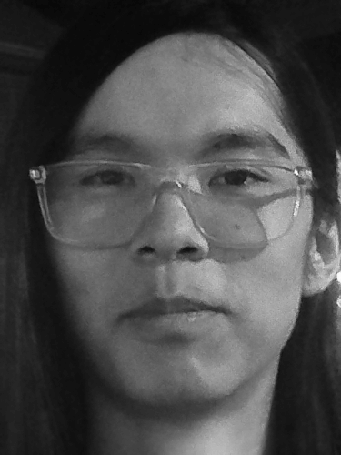

```python
from google.colab.patches import cv2_imshow

face_img = cv2.imread("face2.jpg", cv2.IMREAD_GRAYSCALE)
face_img = cv2.resize(face_img, (375, 500))
cv2.imwrite("face_original.jpg", face_img)

nine_by_nine_box = np.full((9,9), 1/81)
cv2_imshow(face_img)
```

```
Time taken: 12.245411223999326
```

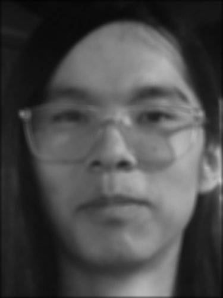

```python
import time
start = time.perf_counter()
box_filtered_4loops = convolve4loops(face_img, nine_by_nine_box)
end = time.perf_counter()
print("Time taken:", end-start)
cv2.imwrite("face_img_4loops.jpg", box_filtered_4loops)
cv2_imshow(box_filtered_4loops)
```

```
Time taken: 0.9876575070002218
```

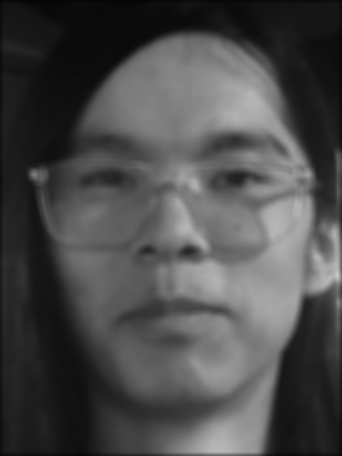

```python
start = time.perf_counter()
box_filtered_2loops = convolve2loops(face_img, nine_by_nine_box)
end = time.perf_counter()
print("Time taken:", end-start)
cv2.imwrite("face_img_2loops.jpg", box_filtered_2loops)
cv2_imshow(box_filtered_2loops)
```

```
Time taken: 0.8861288079997394
```

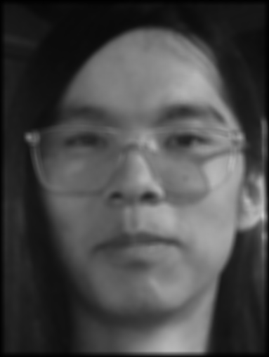

```python
import scipy
start = time.perf_counter()
box_filtered_scipy = scipy.signal.convolve2d(face_img, nine_by_nine_box)
end = time.perf_counter()
print("Time taken:", end-start)
cv2.imwrite("face_img_scipy.jpg", box_filtered_scipy)
cv2_imshow(box_filtered_scipy)
```

The 2 loop function I created seems relatively close in performance to the scipy function (at least for this image), but the 4 loop function is obviously much slower.

$D_x$ and $D_y$ filters

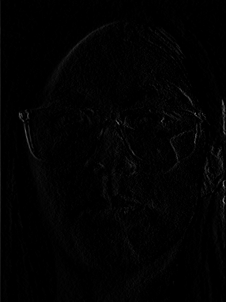

```python
Dx_filter = np.array([[0,0,0],[1,0,-1],[0,0,0]])
dx_filtered = convolve2loops(face_img, Dx_filter)
cv2.imwrite("face_img_dx.jpg", dx_filtered)
cv2_imshow(dx_filtered)
```

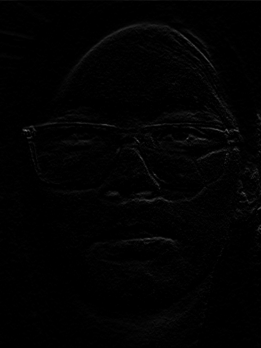

```python
Dy_filter = np.array([[0,1,0],[0,0,0],[0,-1,0]])
dy_filtered = convolve2loops(face_img, Dy_filter)
cv2.imwrite("face_img_dy.jpg", dy_filtered)
cv2_imshow(dy_filtered)
```

# Part 1.2: Finite difference operator

D_x convolution

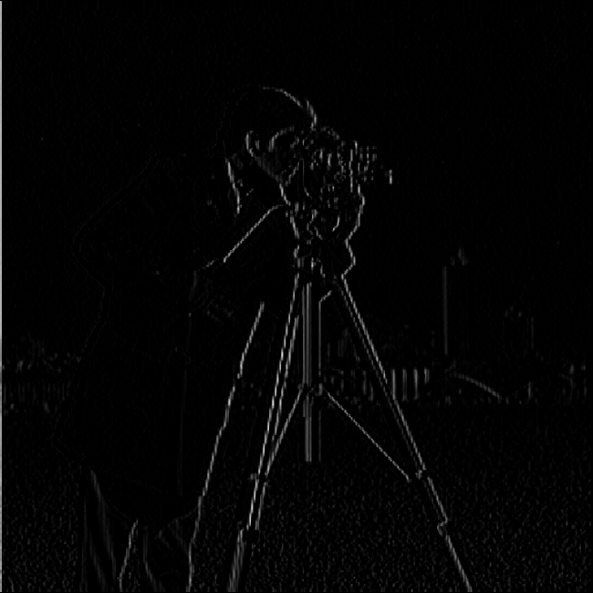

```python
cameraman_img = cv2.imread("The-cameraman-picture.png", cv2.IMREAD_GRAYSCALE)
dx_filtered = scipy.signal.convolve2d(cameraman_img, Dx_filter)
cv2.imwrite("cameraman_dx.jpg", dx_filtered)
cv2_imshow(dx_filtered)
```

D_y convolution

[figure not shown]

```python
dy_filtered = scipy.signal.convolve2d(cameraman_img, Dy_filter)
cv2.imwrite("cameraman_dy.jpg", dy_filtered)
cv2_imshow(dy_filtered)
```

Gradient magnitude image

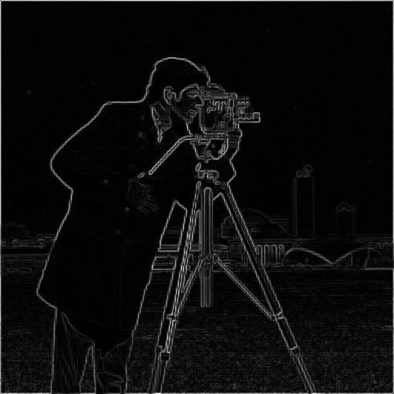

```python
gradient_magnitude = np.sqrt(dx_filtered**2 + dy_filtered**2)
cv2.imwrite("cameraman_gradient_magnitude.jpg", gradient_magnitude)
cv2_imshow(gradient_magnitude)
```

Binarized image

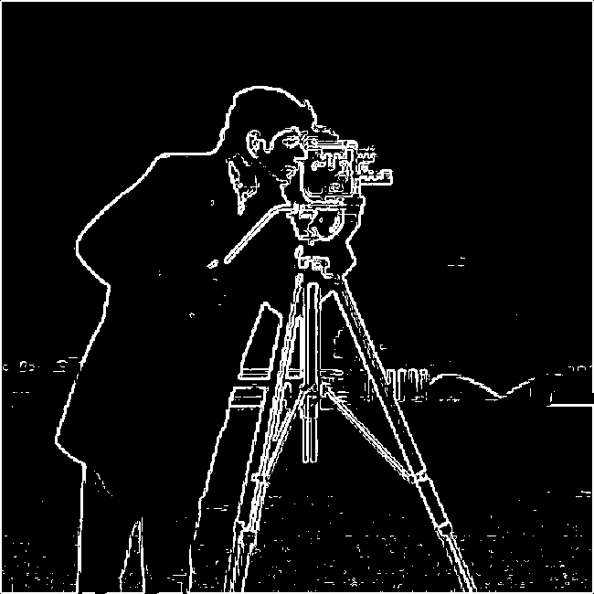

```python
gradient_binarized = 255 * (gradient_magnitude >= 44)
cv2_imshow(gradient_binarized)
```

For picking the cutoff point of 44, this was the highest cutoff point that still generated a sufficient outline of the subject's face (in my opinion), and the noise in the image isn't overwhelming. Moving the cutoff any higher removes all definition of the left edge of the chin.

# Part 1.3: Derivative of Gaussian Filter

Blurring the image

[figure not shown]

```python
gaussian_kernel_1d = cv2.getGaussianKernel(5,1)
gaussian_kernel_2d = np.outer(gaussian_kernel_1d, gaussian_kernel_1d)

blurred_cameraman = scipy.signal.convolve2d(cameraman_img, gaussian_kernel_2d)
cv2_imshow(blurred_cameraman)
```

D_x filter

[figure not shown]

```python
dx_filtered = scipy.signal.convolve2d(blurred_cameraman, Dx_filter)
cv2_imshow(dx_filtered)
```

D_y filter

[figure not shown]

```python
dy_filtered = scipy.signal.convolve2d(blurred_cameraman, Dy_filter)
cv2_imshow(dy_filtered)
```

Gradient magnitude image

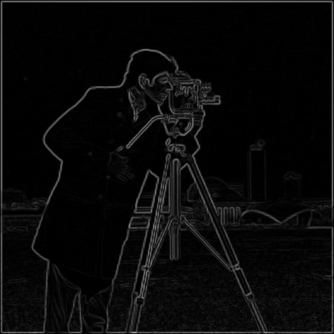

```python
gradient_magnitude = np.sqrt(dx_filtered**2 + dy_filtered**2)
cv2_imshow(gradient_magnitude)
```

Binarization

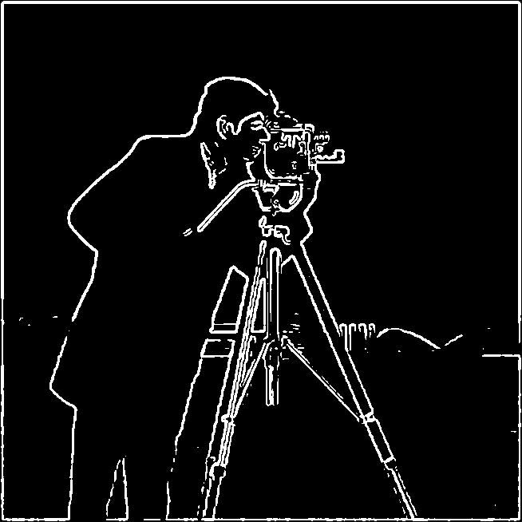

```python
gradient_binarized = 255 * (gradient_magnitude >= 44)
cv2_imshow(gradient_binarized)
```

The chin definition is now missing, but all the hard edges of the person are much smoother now, and there's much less noise in the image. The outlines of the buildings in the background are also less noisy now.

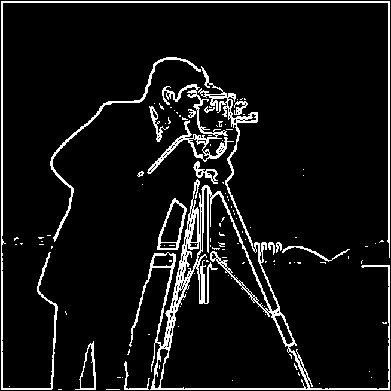

```python
gradient_binarized = 255 * (gradient_magnitude >= 36)
cv2_imshow(gradient_binarized)
```

By tuning the cutoff point, we can get the chin back, and still end up with significantly less noise than previously.

Using a single convolution: D_x filter

```python
Dx_filter_gaussian = scipy.signal.convolve2d(gaussian_kernel_2d, Dx_filter)
dx_filtered_2 = scipy.signal.convolve2d(cameraman_img, Dx_filter_gaussian)
dx_difference = dx_filtered_2 - dx_filtered
print(dx_filtered_2.shape, dx_filtered.shape)
print(np.max(dx_difference))
print(np.min(dx_difference))
```

```
(654, 654) (654, 654)
1.2789769243681803e-13
-1.192379528447418e-13
```

D_y fiter

```python
Dy_filter_gaussian = scipy.signal.convolve2d(gaussian_kernel_2d, Dy_filter)
dy_filtered_2 = scipy.signal.convolve2d(cameraman_img, Dy_filter_gaussian)
dy_difference = dy_filtered_2 - dy_filtered
print(dx_filtered_2.shape, dx_filtered.shape)
print(np.max(dy_difference))
print(np.min(dy_difference))
```

```
(654, 654) (654, 654)
1.389999226830696e-13
-1.2079226507921703e-13
```

As we can see, the resulting filtered images are the same shape, and differences between the pixel values are extremely small (on the order of $10^{-13}$), so both methods effectively produce the same result.

# Bells and whistles

Image with gradient orientation as hue (and gradient strength as value):

[figure not shown]

```python
gradient_orientation = np.arctan2(dy_filtered, dx_filtered) # Calculate gradient orientation (equal to tan^-1(dy/dx))
hue_channel = (gradient_orientation / np.pi * 89.5 + 89.5).astype(np.uint8) # move range from [-pi/2,pi/2] to [0,179]
saturation_channel = np.full_like(hue_channel, 255) # Full saturation for all pixels since we don't have a metric to use here
value_channel = gradient_magnitude.astype(np.uint8) # Value determined by magnitude of gradient

hsv_image = np.stack([hue_channel, saturation_channel, value_channel], 2)
bgr_image = cv2.cvtColor(hsv_image, cv2.COLOR_HSV2BGR)
cv2_imshow(bgr_image)
```

Absolute value of gradients instead (so it doesn't matter if the edge is light to dark or dark to light):

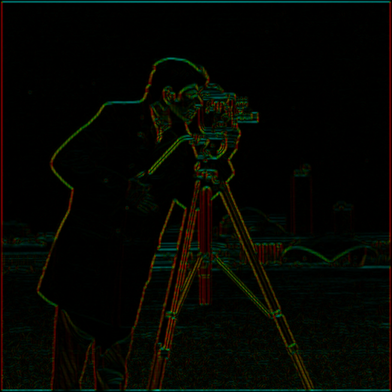

```python
abs_gradient_orientation = np.arctan2(np.abs(dy_filtered), np.abs(dx_filtered))
hue_channel = (abs_gradient_orientation / np.pi * 179).astype(np.uint8) # move range from [0,pi/2] to [0,179]

hsv_image = np.stack([hue_channel, saturation_channel, value_channel], 2)
bgr_image = cv2.cvtColor(hsv_image, cv2.COLOR_HSV2BGR)
cv2_imshow(bgr_image)
```